# IODS course project

# Exercise 5

*Dimensionality reduction techniques*

```r
date()
```

```
## [1] "Thu Dec 03 21:46:10 2020"
```

# Analysis

First of all I will load the some packages:

```r
library(dplyr)
library(ggplot2)
library(GGally)
library(corrplot)
detach("package:MASS", unload = TRUE)
```

## Task 1

Here I will prepare the dataset to use in this analysis. After the preparation, I will show a graphical overview of the data and show summaries of the variables in the data.

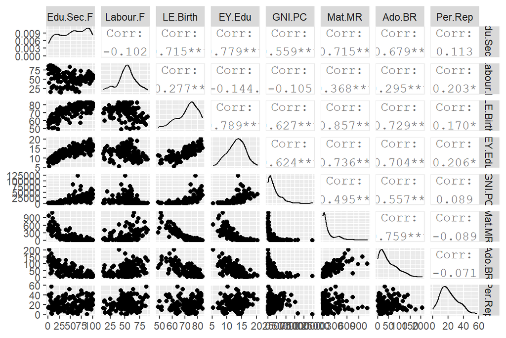

```r
human_clean <- read.csv("human_data.csv")
rownames(human_clean) <- human_clean$X
human_clean <- dplyr::select(human_clean, -X)
ggpairs(human_clean)
```

```r
summary(human_clean)
```

```
##    Edu.Sec.F         Labour.F        LE.Birth         EY.Edu
##  Min.   :  0.90   Min.   :13.50   Min.   :49.00   Min.   : 5.40
##  1st Qu.: 27.15   1st Qu.:44.45   1st Qu.:66.30   1st Qu.:11.25
##  Median : 56.60   Median :53.50   Median :74.20   Median :13.50
##  Mean   : 55.37   Mean   :52.52   Mean   :71.65   Mean   :13.18
##  3rd Qu.: 85.15   3rd Qu.:61.90   3rd Qu.:77.25   3rd Qu.:15.20
##  Max.   :100.00   Max.   :88.10   Max.   :83.50   Max.   :20.20
##      GNI.PC           Mat.MR           Ado.BR          Per.Rep
##  Min.   :   581   Min.   :   1.0   Min.   :  0.60   Min.   : 0.00
##  1st Qu.:  4198   1st Qu.:  11.5   1st Qu.: 12.65   1st Qu.:12.40
##  Median : 12040   Median :  49.0   Median : 33.60   Median :19.30
##  Mean   : 17628   Mean   : 149.1   Mean   : 47.16   Mean   :20.91
##  3rd Qu.: 24512   3rd Qu.: 190.0   3rd Qu.: 71.95   3rd Qu.:27.95
##  Max.   :123124   Max.   :1100.0   Max.   :204.80   Max.   :57.50
```

Now I will explore the distributions of the variables and the relations between them

```r
cor_matrix<-cor(human_clean) %>% round(digits = 2)
print(cor_matrix)
```

```
##           Edu.Sec.F Labour.F LE.Birth EY.Edu GNI.PC Mat.MR Ado.BR Per.Rep
## Edu.Sec.F      1.00    -0.10     0.72   0.78   0.56  -0.72  -0.68    0.11
## Labour.F      -0.10     1.00    -0.28  -0.14  -0.11   0.37   0.30    0.20
## LE.Birth       0.72    -0.28     1.00   0.79   0.63  -0.86  -0.73    0.17
## EY.Edu         0.78    -0.14     0.79   1.00   0.62  -0.74  -0.70    0.21
## GNI.PC         0.56    -0.11     0.63   0.62   1.00  -0.50  -0.56    0.09
## Mat.MR        -0.72     0.37    -0.86  -0.74  -0.50   1.00   0.76   -0.09
## Ado.BR        -0.68     0.30    -0.73  -0.70  -0.56   0.76   1.00   -0.07
## Per.Rep        0.11     0.20     0.17   0.21   0.09  -0.09  -0.07    1.00
```

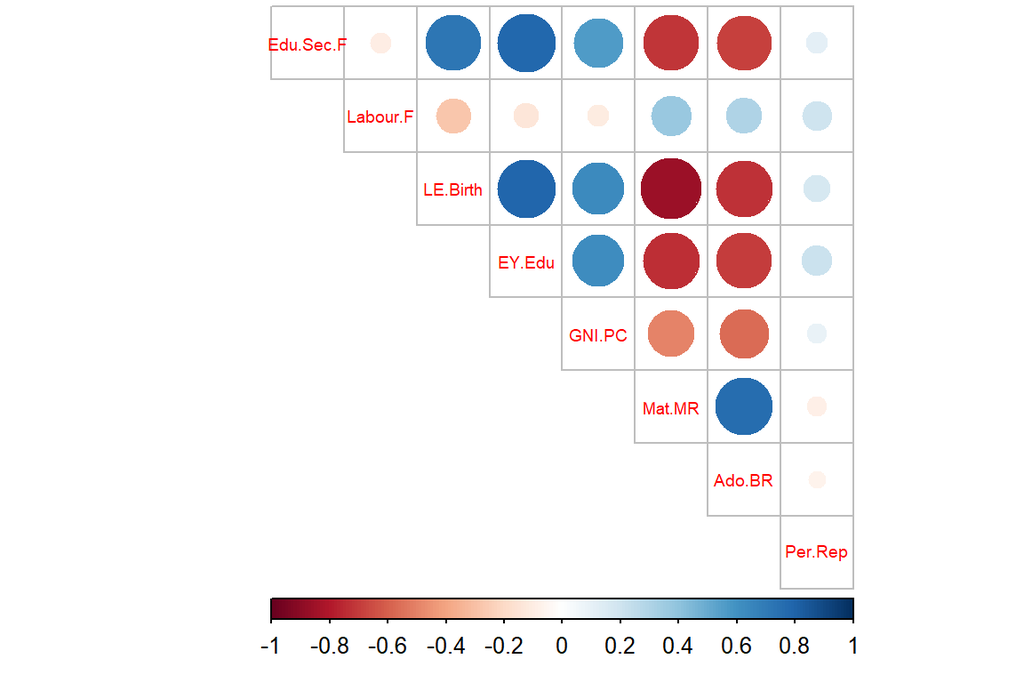

```r
corrplot(cor_matrix, method="circle", type = "upper", cl.pos = "b", tl.pos = "d", tl.cex = 0.6)
```

About the distribution one can immediately observe that the variables have very different range of values, in particular GNI.PC (Gross National Income Per Capita). Moreover, most variables are have highly asymmetrical distributions, e.g. GNI.PC and Mat.MR (Maternal Mortality Ratio). Regarding the relationship between the variables, we can see that some of them show special relations. For example, Female secondary education (Edu.Sec.F) shows a positive correlation with years of education (EY.Edu), and years of education (EY.Edu) has also a positive correlation with life expectancy at birth (LE.Birth). As examples of variables with negative relationship we can cite maternal mortality (Mat.MR) and life expectancy at birth (LE.Birth). Also adolescent birth (Ado.Br) shows negative relation with life expectancy at birth (LE.Birth). The Percentage of Female Representation in Parliament (Per.Rep) is not strongly correlated with the other variables.

## Task 2

Now I will perform a PCA on the not-standardized human data, show the variability captured by the principal components and draw a biplot displaying the observations by the first two principal components.

```r
pca_human <- prcomp(human_clean)
s <- summary(pca_human)
s
```

```
## Importance of components:
##                              PC1      PC2   PC3   PC4   PC5   PC6   PC7   PC8
## Standard deviation     1.854e+04 186.2835 25.97 20.07 14.32 10.63 3.721 1.428
## Proportion of Variance 9.999e-01   0.0001  0.00  0.00  0.00  0.00 0.000 0.000
## Cumulative Proportion  9.999e-01   1.0000  1.00  1.00  1.00  1.00 1.000 1.000
```

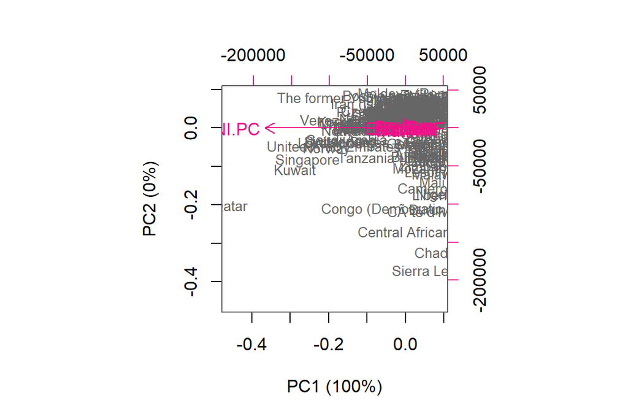

Biplot of non-standardized variables.

```r
pca_pr <- round(100*s$importance[2,], digits = 1)
pc_lab <- paste0(names(pca_pr), " (", pca_pr, "%)")
biplot(pca_human, choices = 1:2, cex = c(0.8, 1), col = c("grey40", "deeppink2"), xlab = pc_lab[1], ylab = pc_lab[2])
```

## Task 3

Now I will perform a PCA on the standardized human data, show the variability captured by the principal components and draw a biplot displaying the observations by the first two principal components.

```r
human_std <- scale(human_clean)
summary(human_std)
```

```
##    Edu.Sec.F           Labour.F           LE.Birth           EY.Edu
##  Min.   :-1.76122   Min.   :-2.43186   Min.   :-2.7188   Min.   :-2.7378
##  1st Qu.:-0.91250   1st Qu.:-0.50289   1st Qu.:-0.6425   1st Qu.:-0.6782
##  Median : 0.03967   Median : 0.06116   Median : 0.3056   Median : 0.1140
##  Mean   : 0.00000   Mean   : 0.00000   Mean   : 0.0000   Mean   : 0.0000
##  3rd Qu.: 0.96275   3rd Qu.: 0.58469   3rd Qu.: 0.6717   3rd Qu.: 0.7126
##  Max.   : 1.44288   Max.   : 2.21762   Max.   : 1.4218   Max.   : 2.4730
##      GNI.PC            Mat.MR            Ado.BR           Per.Rep
##  Min.   :-0.9193   Min.   :-0.6992   Min.   :-1.1325   Min.   :-1.8203
##  1st Qu.:-0.7243   1st Qu.:-0.6496   1st Qu.:-0.8394   1st Qu.:-0.7409
##  Median :-0.3013   Median :-0.4726   Median :-0.3298   Median :-0.1403
##  Mean   : 0.0000   Mean   : 0.0000   Mean   : 0.0000   Mean   : 0.0000
##  3rd Qu.: 0.3712   3rd Qu.: 0.1932   3rd Qu.: 0.6030   3rd Qu.: 0.6127
##  Max.   : 5.6890   Max.   : 4.4899   Max.   : 3.8344   Max.   : 3.1850
```

```r
pca_human_std <- prcomp(human_std)
s_std <- summary(pca_human_std)
s_std
```

```
## Importance of components:
##                           PC1    PC2     PC3     PC4     PC5    PC6     PC7
## Standard deviation     2.1360 1.1171 0.87671 0.72027 0.55309 0.5299 0.44935
## Proportion of Variance 0.5703 0.1560 0.09608 0.06485 0.03824 0.0351 0.02524
## Cumulative Proportion  0.5703 0.7263 0.82235 0.88720 0.92544 0.9605 0.98578
##                            PC8
## Standard deviation     0.33728
## Proportion of Variance 0.01422
## Cumulative Proportion  1.00000
```

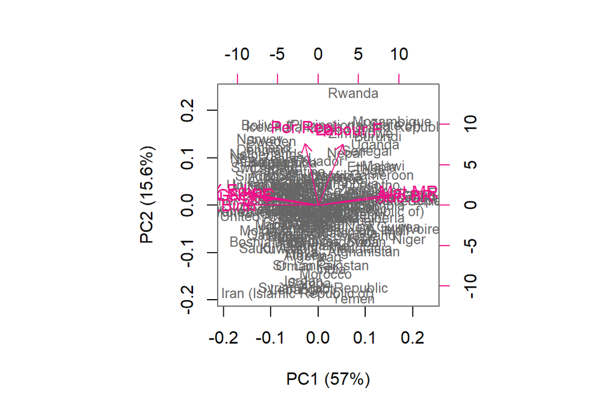

Biplot of standardized variables. Expected Years of Education, Female Secondary Education, Gross income percapita and Life Expectancy at Birth are aligned with PC1, showing a relationsip between them. Maternal mortality and early pregnancy also also have conection with PC1, but in nearly opposite direction as the other variables given the nearly 180 degrees separation between them.

```r
pca_pr <- round(100*s_std$importance[2,], digits = 1)
pc_lab <- paste0(names(pca_pr), " (", pca_pr, "%)")
biplot(pca_human_std, cex = c(0.8, 1), col = c("grey40", "deeppink2"), xlab = pc_lab[1], ylab = pc_lab[2])
```

The results in both plots are very different because the non-standardized data concentrate nearly 100% of the information in PC1 and the values of the PCs vary significantly. Conversely, the standardized data shows PC values better divided and distributed, even though PC1 still concentrates 57% of the information.

## Task 4

My personal interpretations of the first two principal component dimensions based on the biplot drawn after PCA on the standardized human data is that the PCA captures the fact that Per.Rep and and Labour.F variables have relatively low correlation with all the other variables in the set. This can be seen by the fact that those variables are mostly in the direction of PC2. Moreover, the remaining variables have similar cross-correlation between them (with possible exeption of the sign), which can be seen in the fact that all these variables are relatively aligned along the axis of main component PC1.